# Assignment 3 Task 3 - Mari Herbst de Cortina

Mari Herbst

10/24/2021

```r
knitr::opts_chunk$set(echo = TRUE, message = FALSE, warning = FALSE)

library(here)
library(tidyverse)
library(dplyr)
library(janitor)
library(kableExtra)
library(lubridate)
```

# Exploring Urchins

#### data citation: Reed, D. 2020. SBC LTER: Reef: Long-term experiment: Kelp removal: Urchin size frequency distribution ver 20. Environmental Data Initiative. https://doi.org/10.6073/pasta/5a1e9ef03aa47bd2225c0bb98a02a63b.

#### This data measures red and purple urchin populations and diameter (to nearest 0.5 cm) at 5 sites between 2008 and 2020. The data collection related to urchin populations where giant kelp is left intact vs where it is removed once annually.

### Read in the data using here() to create a system agnostic file path

```r
urchins <- read_csv(here("data", "urchins.csv"))
```

## Section 1: size comparisons for purple and red urchins

- First, I want to make the data more coder friendly.

```r
clean_urchins <- clean_names(urchins)
```

### Data visualization - histogram

- Select dataframe and the variable to be counted.
- Choose the type of graph, in this case, we are making a histogram. Also, select the variable by which to color code and select the number of bins for the histogram to organize data into.
- Use labs() to name axes, title, and legend title.
- Use facet_wrap() to divide the graph into 2 histograms, one for each common name of urchins.

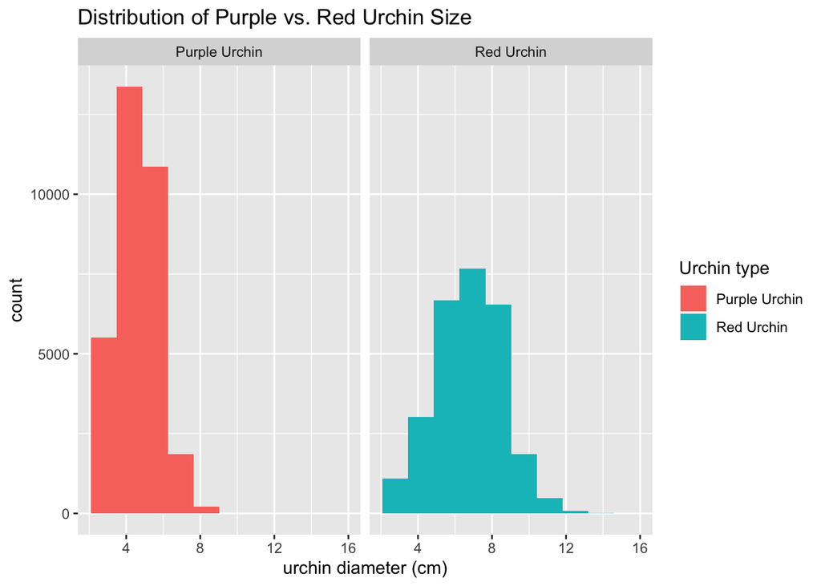

```r
ggplot(data = clean_urchins, aes(x = size)) +
  geom_histogram(bins = 10, aes(fill = common_name)) +
  labs(x = "urchin diameter (cm)",
       title = "Distribution of Purple vs. Red Urchin Size",
       legend = "Urchin species",
       fill = "Urchin type") +
  facet_wrap(vars(common_name))
```

### Descriptive statistics table - summary table

- Create a summary table grouped by urchin type that includes the mean and median size, the standard deviation in size, and the sample size for each urchin type.
- Be sure to use kable() to name columns appropriately and with units!

```r
urchins_summary <- clean_urchins %>%
  group_by(common_name) %>%
  summarize(mean_size_cm = round(mean(size, na.rm = TRUE), 2),
            median_size_cm = round(median(size), 2),
            sd_size = round(sd(size), 2),
            sample_size = n())

urchins_summary %>%
  kable(col.names = c("Species",
                      "Mean diameter (cm)",
                      "Median diameter (cm)",
                      "Standard deviation (cm)",
                      "Sample Size"),
        caption = "Table 1: A summary of urchin sizes showing the mean and median size, standard deviation in size, and sample size of each type of urchin that was studied.")
```

Table 1: A summary of urchin sizes showing the mean and median size, standard deviation in size, and sample size of each type of urchin that was studied.

| Species | Mean diameter (cm) | Median diameter (cm) | Standard deviation (cm) | Sample Size |
| --- | --- | --- | --- | --- |
| Purple Urchin | 4.47 | 4.5 | 1.18 | 31805 |
| Red Urchin | 6.78 | 7.0 | 1.89 | 27408 |

##### In general, red urchins are larger than purple urchins in this study area; the average purple urchin is 2.31cm smaller than the average red one. Red urchins are, on average, 1.52 times as large as purple urchins. There is a greater degree of spread amongst red urchins, indicated by the higher standard deviation figure.

## Section 2: urchin counts by site and year

### Create a subset of data

```r
purple_urchins <- clean_urchins %>%
  filter(common_name == "Purple Urchin") %>%
  mutate(date = mdy(date)) %>%
  separate(col = date,
           into = c("year", "month_day"),
           sep = "-",
           extra = "merge",
           remove = TRUE) %>%
  mutate(site_full = case_when(
    site %in% c("NAPL") ~ "Naples Reef",
    site %in% c("AQUE") ~ "Arroyo Quemado Reef",
    site %in% c("CARP") ~ "Carpinteria Reef",
    site %in% c("MOHK") ~ "Mohawk Reef",
    site %in% c("IVEE") ~ "Isla Vista Reef"))
```

### Create a table containing the total number of purple urchins observed by site and year

- Use group_by() to select site_full and year
- Summarize by sample size using n()

```r
purple_urchin_count <- purple_urchins %>%
  group_by(site_full, year) %>%
  summarize(total_urchins = n())
```

### Create a graph of purple_urchin_count site

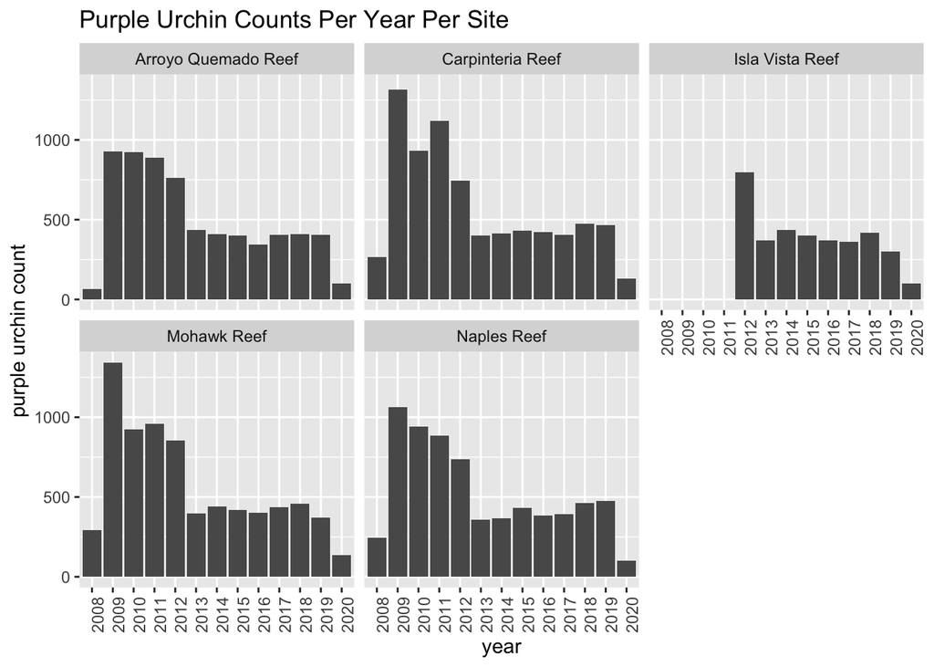

```r
ggplot(data = purple_urchin_count, aes(x = year, y = total_urchins)) +
  geom_col() +
  labs(x = "year",
       y = "purple urchin count",
       title = "Purple Urchin Counts Per Year Per Site") +
  theme(axis.text.x = element_text(angle = 90)) + # change angle of x axis values to make easier to read
  facet_wrap(~ site_full)
```

## END TASK 3